[Voltar](http://victorpasson.github.io/)

# Três Meses de Vacinação - Espírito Santo

João Victor - @victorpasson

06/04/2021

## **Visão Geral**

No dia 17 de Janeiro de 2021 deu-se início ao processo de vacinação contra COVID no Espírito Santo. Em um processo lento, com falta de insumos, seguimos ao pouco vacinando a população. Começando por grupos prioritários baseado na idade e profissão busca-se reduzir a mortalidade do virus para que possamos voltar a vida próximo ao que era antes de tudo.

Por meio de gráficos iremos tentar entender o que tem acontecido com a vacinação por faixa etária, profissionais da saúde e o total da população em contraste com a curva de óbitos.

## **Dados**

Os dados foram todos retirados de sites oficiais.

A base que usamos para os óbitos referentes a COVID no Espírito Santo foram retiradas do site do Governo Estadual próprio para a doença, pode ser acessada [clicando aqui](https://coronavirus.es.gov.br/painel-covid-19-es).

Já os dados referentes a vacinação são do Ministério da Saúde retiradas por meio do Sistema de Informação do Programa Nacional de Imunizações, os dados podem ser acessados [clicando aqui](https://opendatasus.saude.gov.br/dataset/covid-19-vacinacao).

## **Execução do Script**

Primeiro iremos adequar os datasets para que possamos gerar os gráficos.

### Dataset Vacinação

```r
# Carregando dataset de vacinação
vacinas <- fread("part-00000-a5cf54e8-07ec-4455-873c-da8b365ee372.c000.csv")

# Visualizando formatação
head(vacinas)
```

```r
glimpse(vacinas)
```

```
## Rows: 469,054
## Columns: 33
## $ document_id                              <chr> "be3b387f-4b2c-450d-8191-3a9d~
## $ paciente_id                              <chr> "1fd5bfe30cc87a40b8338d68c7f8~
## $ paciente_idade                           <int> 40, 80, 29, 46, 44, 86, 98, 7~
## $ paciente_dataNascimento                  <date> 1980-02-18, 1941-01-09, 1991~
## $ paciente_enumSexoBiologico               <chr> "F", "M", "F", "F", "F", "F",~
## $ paciente_racaCor_codigo                  <int> 99, 3, 3, 1, 1, 99, 99, 3, 99~
## $ paciente_racaCor_valor                   <chr> "SEM INFORMACAO", "PARDA", "P~
## $ paciente_endereco_coIbgeMunicipio        <int> 320150, 320080, 320500, 32014~
## $ paciente_endereco_coPais                 <int> 10, 10, 10, 10, 10, 10, 10, 1~
## $ paciente_endereco_nmMunicipio            <chr> "COLATINA", "BAIXO GUANDU", "~
## $ paciente_endereco_nmPais                 <chr> "BRASIL", "BRASIL", "BRASIL",~
## $ paciente_endereco_uf                     <chr> "ES", "ES", "ES", "ES", "ES",~
## $ paciente_endereco_cep                    <int> 29701, 29730, 29178, 29360, 2~
```

[output cut: 20 more lines]

```r
# Verificando se existem dados NA's
sum(is.na(vacinas$vacina_dataAplicacao))
```

```
## [1] 0
```

```r
sum(is.na(vacinas$paciente_idade))
```

```
## [1] 0
```

```r
sum(is.na(vacinas$paciente_endereco_nmMunicipio))
```

```
## [1] 0
```

```r
# Só as colunas de interesse e mudando o nome
vacinas <- vacinas[, c("vacina_dataAplicacao", "paciente_idade", "paciente_endereco_nmMunicipio", "vacina_categoria_nome")]
names(vacinas) <- c("data", "idade", "municipio", "categoria")

# Categorias disponíveis de vacinação
unique(vacinas$categoria)
```

```
##  [1] "Trabalhadores de SaÃºde"
##  [2] "Faixa EtÃ¡ria"
##  [3] "Pessoas de 60 anos ou mais institucionalizadas"
##  [4] "Povos IndÃgenas"
##  [5] "Povos e Comunidades Tradicionais"
##  [6] "Pessoas com DeficiÃªncia"
##  [7] "FuncionÃ¡rio do Sistema de PrivaÃ§Ã£o de Liberdade"
##  [8] "Trabalhadores da EducaÃ§Ã£o"
##  [9] "PopulaÃ§Ã£o Privada de Liberdade"
## [10] "Comorbidades"
## [11] ""
## [12] "Trabalhadores Industriais"
## [13] "ForÃ§as de SeguranÃ§a e Salvamento"
## [14] "Pessoas em SituaÃ§Ã£o de Rua"
```

```r
# Tipo das colunas
glimpse(vacinas)
```

```
## Rows: 469,054
## Columns: 4
## $ data      <dttm> 2021-02-10 03:00:00, 2021-03-08 03:00:00, 2021-02-25 03:00:~
## $ idade     <int> 40, 80, 29, 46, 44, 86, 98, 76, 54, 80, 87, 93, 68, 90, 26, ~
## $ municipio <chr> "COLATINA", "BAIXO GUANDU", "SERRA", "CASTELO", "PANCAS", "C~
## $ categoria <chr> "Trabalhadores de SaÃºde", "Faixa EtÃ¡ria", "Trabalhadores d~
```

```r
# Formatando a data
vacinas$data <-  format(vacinas$data, "%Y-%m-%d")
vacinas$data <- ymd(vacinas$data)

# Nova variável: semana de vacinação
vacinas$week <- week(vacinas$data)

# Data de início da vacinação
min(vacinas$data)
```

```
## [1] "2021-01-17"
```

```r
# Último dia de dados de vacinação que temos
max(vacinas$data)
```

```
## [1] "2021-04-04"
```

### Dataset Óbitos

```r
# Carregando o dataset
covid <- fread("MICRODADOS.csv")

# Nome das colunas
names(covid)
```

```
##  [1] "DataNotificacao"         "DataCadastro"
##  [3] "DataDiagnostico"         "DataColeta_RT_PCR"
##  [5] "DataColetaTesteRapido"   "DataColetaSorologia"
##  [7] "DataColetaSorologiaIGG"  "DataEncerramento"
##  [9] "DataObito"               "Classificacao"
## [11] "Evolucao"                "CriterioConfirmacao"
## [13] "StatusNotificacao"       "Municipio"
## [15] "Bairro"                  "FaixaEtaria"
## [17] "IdadeNaDataNotificacao"  "Sexo"
## [19] "RacaCor"                 "Escolaridade"
## [21] "Febre"                   "DificuldadeRespiratoria"
## [23] "Tosse"                   "Coriza"
## [25] "DorGarganta"             "Diarreia"
## [27] "Cefaleia"                "ComorbidadePulmao"
## [29] "ComorbidadeCardio"       "ComorbidadeRenal"
## [31] "ComorbidadeDiabetes"     "ComorbidadeTabagismo"
## [33] "ComorbidadeObesidade"    "FicouInternado"
## [35] "ViagemBrasil"            "ViagemInternacional"
## [37] "ProfissionalSaude"       "PossuiDeficiencia"
## [39] "MoradorDeRua"            "ResultadoRT_PCR"
## [41] "ResultadoTesteRapido"    "ResultadoSorologia"
## [43] "ResultadoSorologia_IGG"
```

```r
# Selecionando as colunas de interesse
covid <- covid[, c("DataObito", "Evolucao", "Municipio", "FaixaEtaria", "IdadeNaDataNotificacao", "ProfissionalSaude")]
```

```r
# Categorias de óbito ou não
unique(covid$Evolucao)
```

```
## [1] "-"                       "Ignorado"
## [3] "Cura"                    "Óbito pelo COVID-19"
## [5] "Óbito por outras causas"
```

```r
# Categorias de Idade
unique(covid$FaixaEtaria)
```

```
##  [1] "30 a 39 anos"    "05 a 9 anos"     "20 a 29 anos"    "40 a 49 anos"
##  [5] "60 a 69 anos"    "10 a 19 anos"    "0 a 4 anos"      "50 a 59 anos"
##  [9] "90 anos ou mais" "80 a 89 anos"    "70 a 79 anos"    "-"
```

```r
# Se é Profissional da Saúde
unique(covid$ProfissionalSaude)
```

```
## [1] "Não"           "Sim"           "Ignorado"      "Não Informado"
```

```r
# Formato dos dados
glimpse(covid)
```

```
## Rows: 1,208,627
## Columns: 6
## $ DataObito              <date> NA, NA, NA, NA, NA, NA, NA, NA, NA, NA, NA, NA~
## $ Evolucao               <chr> "-", "-", "Ignorado", "-", "Ignorado", "-", "-"~
## $ Municipio              <chr> "MUQUI", "SERRA", "CACHOEIRO DE ITAPEMIRIM", "S~
## $ FaixaEtaria            <chr> "30 a 39 anos", "05 a 9 anos", "20 a 29 anos", ~
## $ IdadeNaDataNotificacao <chr> "32 anos, 6 meses, 22 dias", "8 anos, 5 meses, ~
## $ ProfissionalSaude      <chr> "Não", "Não", "Sim", "Não", "Sim", "Sim", "Não"~
```

```r
# Formatando as datas
covid$DataObito <- ymd(covid$DataObito)

# Nova variável: semana do óbito
covid$week <- week(covid$DataObito)

# Visualização
head(covid)
```

```
##    DataObito Evolucao               Municipio  FaixaEtaria
## 1:      <NA>        -                   MUQUI 30 a 39 anos
## 2:      <NA>        -                   SERRA  05 a 9 anos
## 3:      <NA> Ignorado CACHOEIRO DE ITAPEMIRIM 20 a 29 anos
## 4:      <NA>        -                   SERRA  05 a 9 anos
## 5:      <NA> Ignorado CACHOEIRO DE ITAPEMIRIM 40 a 49 anos
## 6:      <NA>        -              VILA VELHA 30 a 39 anos
##       IdadeNaDataNotificacao ProfissionalSaude week
## 1: 32 anos, 6 meses, 22 dias               Não   NA
## 2:  8 anos, 5 meses, 27 dias               Não   NA
## 3: 24 anos, 3 meses, 20 dias               Sim   NA
## 4:  5 anos, 2 meses, 10 dias               Não   NA
## 5: 48 anos, 5 meses, 22 dias               Sim   NA
## 6:  38 anos, 0 meses, 4 dias               Sim   NA
```

```r
# Selecionando somente os Óbitos
covid <- covid[covid$Evolucao == "Óbito pelo COVID-19",]

# Visualizando
head(covid)
```

```
##     DataObito            Evolucao        Municipio  FaixaEtaria
## 1: 2021-04-03 Óbito pelo COVID-19            MUQUI 80 a 89 anos
## 2: 2021-04-03 Óbito pelo COVID-19          VITORIA 80 a 89 anos
## 3: 2021-04-01 Óbito pelo COVID-19          VITORIA 80 a 89 anos
## 4: 2021-04-01 Óbito pelo COVID-19     MANTENOPOLIS 70 a 79 anos
## 5: 2021-04-05 Óbito pelo COVID-19 DOMINGOS MARTINS 50 a 59 anos
## 6: 2021-04-03 Óbito pelo COVID-19            SERRA 60 a 69 anos
##       IdadeNaDataNotificacao ProfissionalSaude week
## 1: 82 anos, 1 meses, 21 dias               Não   14
## 2: 86 anos, 2 meses, 25 dias          Ignorado   14
## 3: 88 anos, 3 meses, 22 dias          Ignorado   13
## 4: 76 anos, 2 meses, 26 dias               Não   13
## 5:  55 anos, 0 meses, 7 dias               Não   14
## 6: 60 anos, 5 meses, 18 dias               Não   14
```

```r
# Equalizando as faixas etárias de Vacinação e Óbito
unique(covid$FaixaEtaria)
```

```
##  [1] "80 a 89 anos"    "70 a 79 anos"    "50 a 59 anos"    "60 a 69 anos"
##  [5] "10 a 19 anos"    "30 a 39 anos"    "90 anos ou mais" "40 a 49 anos"
##  [9] "20 a 29 anos"    "0 a 4 anos"      "05 a 9 anos"
```

```r
vacinas$FaixaEtaria <- ifelse(vacinas$idade <= 4, "0 a 4 anos",
                             ifelse(vacinas$idade >=5 & vacinas$idade <= 9, "05 a 9 anos",
                                                                      ifelse(vacinas$idade >=10 & vacinas$idade <=19, "10 a 19 anos",
                                                                             ifelse(vacinas$idade >= 20 & vacinas$idade <= 29, "20 a 29 anos",
                                                                                    ifelse(vacinas$idade >= 30 & vacinas$idade <= 39, "30 a 39 anos",
                                                                                           ifelse(vacinas$idade >= 40 & vacinas$idade <= 49, "40 a 49 anos",
                                                                                                  ifelse(vacinas$idade >= 50 & vacinas$idade <= 59, "50 a 59 anos",
                                                                                                         ifelse(vacinas$idade >= 60 & vacinas$idade <= 69, "60 a 69 anos",
                                                                                                                ifelse(vacinas$idade >= 70 & vacinas$idade <= 79, "70 a 79 anos",
                                                                                                                       ifelse(vacinas$idade >= 80 & vacinas$idade <= 89, "80 a 89 anos", "90 anos ou mais"))))))))))
```

## **Gerando Gráficos**

A partir de cada gráfico iremos acrescentendo um grupo de vacinação ao total.

### Acima de 90 Anos

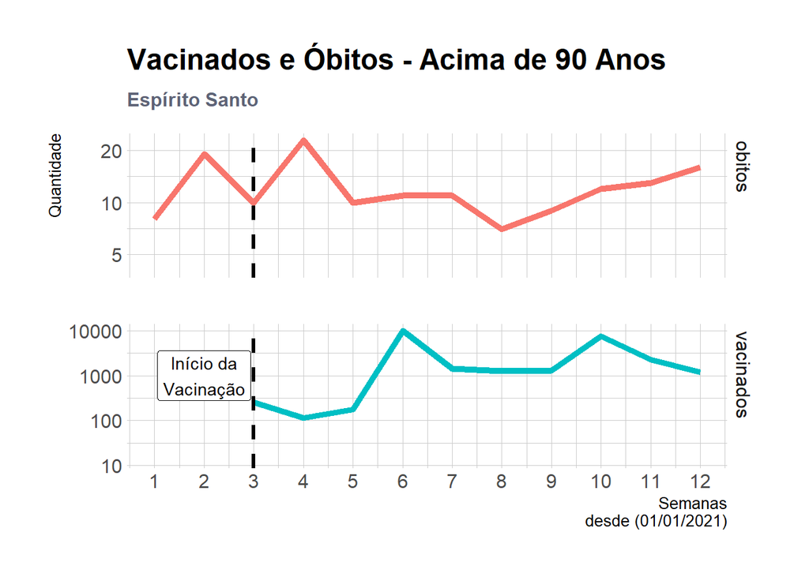

```r
# Evolução semanal de Mortes x Vacinação 90 anos ou mais
covid %>%
  filter(FaixaEtaria == "90 anos ou mais" & DataObito >= "2021-01-01") %>%
  group_by(week) %>%
  summarise(obitos = n()) %>%
  left_join(y = vacinas %>%
              filter(FaixaEtaria == "90 anos ou mais") %>%
              group_by(week) %>%
              summarise(vacinados = n()),
            by = c("week" = "week")) %>%
  gather("obitos", "vacinados", -week) %>%
  drop_na() %>%
  ggplot() +
  geom_line(aes(x = week, y = vacinados, color = obitos), size = 1.8) +
  facet_grid(obitos ~ ., scales = "free_y") +
  geom_vline(xintercept = 3, size = 1.2, linetype="dashed", color = "black") +
  geom_label(x = 2, y = 3, label = "Início da\nVacinação") +
  scale_y_log10() +
  scale_x_continuous(n.breaks = 12, limits = c(1, 12)) +
  scale_color_discrete(guide = FALSE) +
  labs(title = "Vacinados e Óbitos - Acima de 90 Anos", subtitle = "Espírito Santo",
       x = "Semanas\ndesde (01/01/2021)",
       y = "Quantidade",
       colour = NULL) +
  theme_ipsum_pub(base_family = 12, base_size = 12, axis_title_size = 10) +
  theme(legend.text = element_text(NULL),
        plot.subtitle = element_text(vjust = 1, size = 12, colour = "#5E6376", face = "bold"))
```

A tendência de óbitos das pessoas acima de 90 anos ainda é de crescimento desde a oitava semana de 2021. Porém, a taxa de óbito ainda é menos do que a atingida na quarta semana epidemiológica.

### Acima de 80 anos

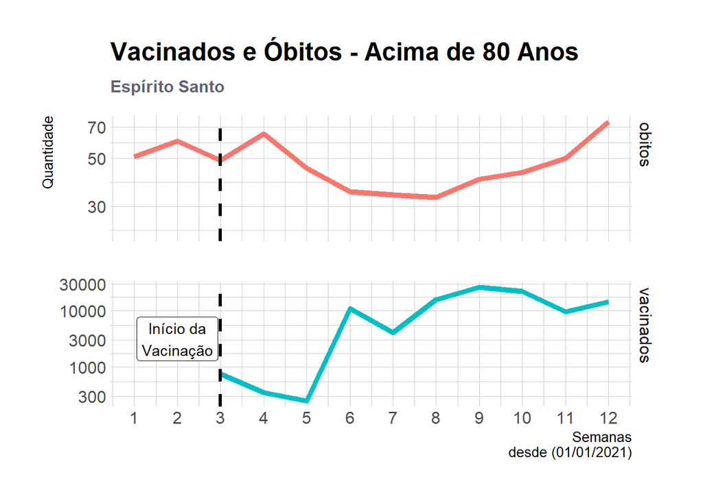

```r
# Evolução semanal de Mortes x Vacinação 80 anos ou mais
covid %>%
  filter((FaixaEtaria == "90 anos ou mais" | FaixaEtaria == "80 a 89 anos") & DataObito >= "2021-01-01") %>%
  group_by(week) %>%
  summarise(obitos = n()) %>%
  left_join(y = vacinas %>%
              filter(FaixaEtaria == "90 anos ou mais" | FaixaEtaria == "80 a 89 anos") %>%
              group_by(week) %>%
              summarise(vacinados = n()),
            by = c("week" = "week")) %>%
  gather("obitos", "vacinados", -week) %>%
  drop_na() %>%
  ggplot() +
  geom_line(aes(x = week, y = vacinados, color = obitos), size = 1.8) +
  facet_grid(obitos ~ ., scales = "free_y") +
  geom_vline(xintercept = 3, size = 1.2, linetype="dashed", color = "black") +
  geom_label(x = 2, y = 3.5, label = "Início da\nVacinação") +
  scale_y_log10() +
  scale_x_continuous(n.breaks = 12, limits = c(1, 12)) +
  scale_color_discrete(guide = FALSE) +
  labs(title = "Vacinados e Óbitos - Acima de 80 Anos", subtitle = "Espírito Santo",
       x = "Semanas\ndesde (01/01/2021)",
       y = "Quantidade",
       colour = NULL) +
  theme_ipsum_pub(base_family = 12, base_size = 12, axis_title_size = 10) +
  theme(legend.text = element_text(NULL),
        plot.subtitle = element_text(vjust = 1, size = 12, colour = "#5E6376", face = "bold"))
```

Novamente têm-se a tendência de crescimento nos óbitos dede a oitava semana do ano. Aqui já tem-se óbitos maiores do que os atingidos na quarta semana epidemiológica.

### Acima de 70 anos

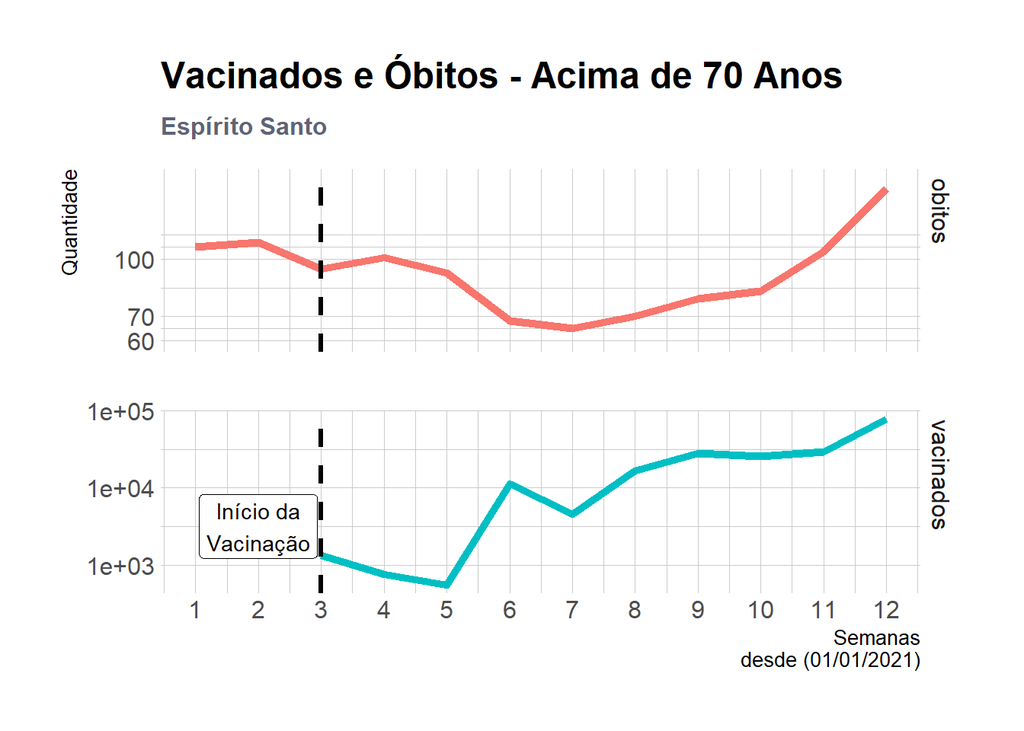

```r
# Evolução semanal de Mortes x Vacinação 70 anos ou mais
covid %>%
  filter((FaixaEtaria == "90 anos ou mais" | FaixaEtaria == "80 a 89 anos" |
            FaixaEtaria == "70 a 79 anos") & DataObito >= "2021-01-01") %>%
  group_by(week) %>%
  summarise(obitos = n()) %>%
  left_join(y = vacinas %>%
              filter(FaixaEtaria == "90 anos ou mais" | FaixaEtaria == "80 a 89 anos" |
                       FaixaEtaria == "70 a 79 anos") %>%
              group_by(week) %>%
              summarise(vacinados = n()),
            by = c("week" = "week")) %>%
  gather("obitos", "vacinados", -week) %>%
  drop_na() %>%
  ggplot() +
  geom_line(aes(x = week, y = vacinados, color = obitos), size = 1.8) +
  facet_grid(obitos ~ ., scales = "free_y") +
  geom_vline(xintercept = 3, size = 1.2, linetype="dashed", color = "black") +
  geom_label(x = 2, y = 3.5, label = "Início da\nVacinação") +
  scale_y_log10() +
  scale_x_continuous(n.breaks = 12, limits = c(1, 12)) +
  scale_color_discrete(guide = FALSE) +
  labs(title = "Vacinados e Óbitos - Acima de 70 Anos", subtitle = "Espírito Santo",
       x = "Semanas\ndesde (01/01/2021)",
       y = "Quantidade",
       colour = NULL) +
  theme_ipsum_pub(base_family = 12, base_size = 12, axis_title_size = 10) +
  theme(legend.text = element_text(NULL),
        plot.subtitle = element_text(vjust = 1, size = 12, colour = "#5E6376", face = "bold"))
```

A partir de 70 anos ou mais já é possível observar a explosão dos óbitos, superando, e muito, os atingidos na segunda e quarta semana epidemiológica.

### Acima de 60 anos

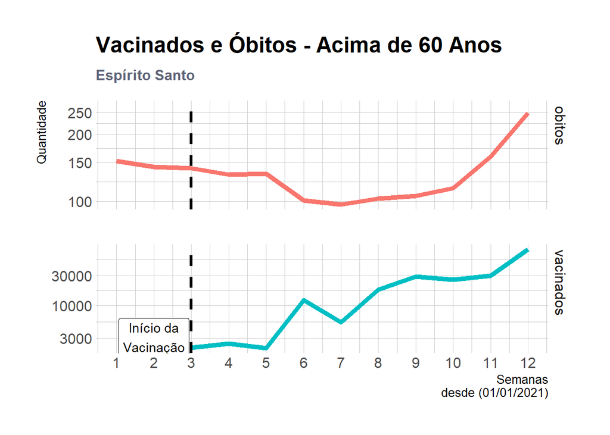

```r
# Evolução semanal de Mortes x Vacinação 60 anos ou mais
covid %>%
  filter((FaixaEtaria == "90 anos ou mais" | FaixaEtaria == "80 a 89 anos" |
            FaixaEtaria == "70 a 79 anos" | FaixaEtaria == "60 a 69 anos") & DataObito >= "2021-01-01") %>%
  group_by(week) %>%
  summarise(obitos = n()) %>%
  left_join(y = vacinas %>%
              filter(FaixaEtaria == "90 anos ou mais" | FaixaEtaria == "80 a 89 anos" |
                       FaixaEtaria == "70 a 79 anos" | FaixaEtaria == "60 a 69 anos") %>%
              group_by(week) %>%
              summarise(vacinados = n()),
            by = c("week" = "week")) %>%
  gather("obitos", "vacinados", -week) %>%
  drop_na() %>%
  ggplot() +
  geom_line(aes(x = week, y = vacinados, color = obitos), size = 1.8) +
  facet_grid(obitos ~ ., scales = "free_y") +
  geom_vline(xintercept = 3, size = 1.2, linetype="dashed", color = "black") +
  geom_label(x = 2, y = 3.5, label = "Início da\nVacinação") +
  scale_y_log10() +
  scale_x_continuous(n.breaks = 12, limits = c(1, 12)) +
  scale_color_discrete(guide = FALSE) +
  labs(title = "Vacinados e Óbitos - Acima de 60 Anos", subtitle = "Espírito Santo",
       x = "Semanas\ndesde (01/01/2021)",
       y = "Quantidade",
       colour = NULL) +
  theme_ipsum_pub(base_family = 12, base_size = 12, axis_title_size = 10) +
  theme(legend.text = element_text(NULL),
        plot.subtitle = element_text(vjust = 1, size = 12, colour = "#5E6376", face = "bold"))
```

### Profissionais da Saúde

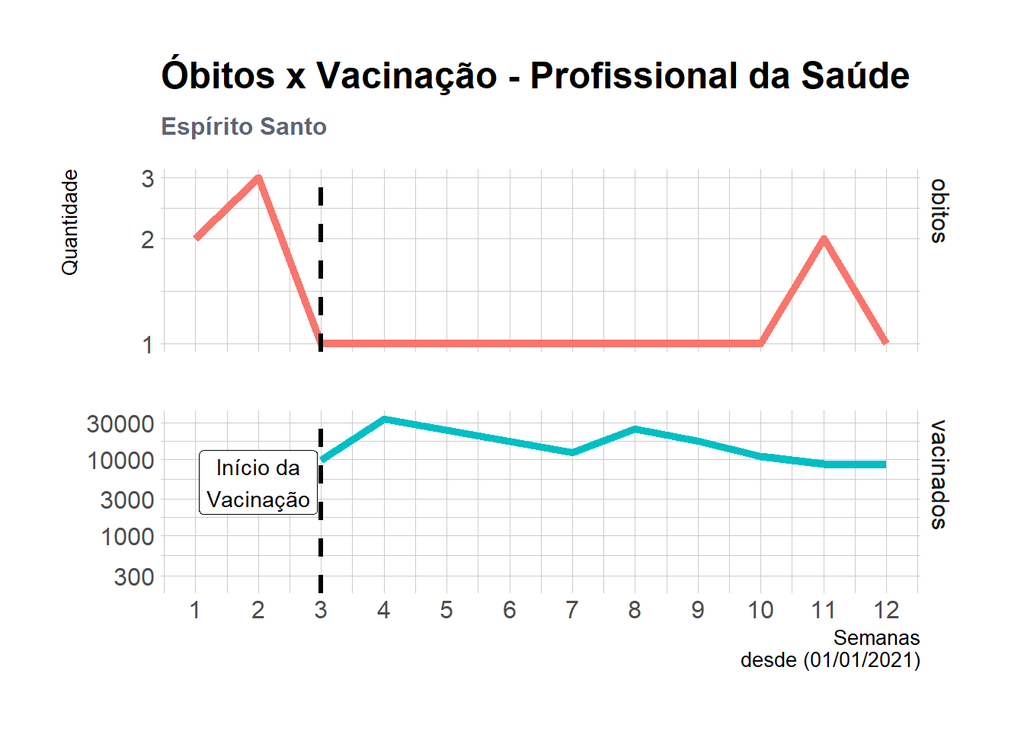

```r
# Profissionais da Saúde
covid %>%
  filter(DataObito >= "2021-01-01" & ProfissionalSaude == "Sim") %>%
  group_by(week) %>%
  summarise(obitos = n()) %>%
  left_join(y = vacinas %>%
              filter(categoria == "Trabalhadores de SaÃºde") %>%
              group_by(week) %>%
              summarise(vacinados = n()),
            by = c("week" = "week")) %>%
  gather("obitos", "vacinados", -week) %>%
  drop_na() %>%
  ggplot() +
  geom_line(aes(x = week, y = vacinados, color = obitos), size = 1.8) +
  facet_grid(obitos ~ ., scales = "free_y") +
  geom_vline(xintercept = 3, size = 1.2, linetype="dashed", color = "black") +
  geom_label(x = 2, y = 3.7, label = "Início da\nVacinação") +
  scale_y_log10() +
  scale_x_continuous(n.breaks = 12, limits = c(1, 12)) +
  scale_color_discrete(guide = FALSE) +
  labs(title = "Óbitos x Vacinação - Profissional da Saúde", subtitle = "Espírito Santo",
       x = "Semanas\ndesde (01/01/2021)",
       y = "Quantidade",
       colour = NULL) +
  theme_ipsum_pub(base_family = 12, base_size = 12, axis_title_size = 10) +
  theme(legend.text = element_text(NULL),
        plot.subtitle = element_text(vjust = 1, size = 12, colour = "#5E6376", face = "bold"))
```

### Exceto os grupos já postos

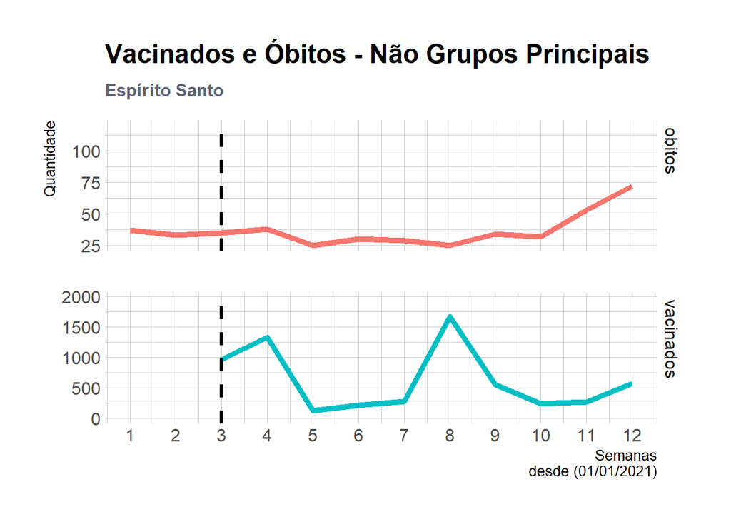

```r
# Óbito e vacinação não grupo prioritário, não profissional da saúde
covid %>%
  filter((FaixaEtaria != "90 anos ou mais" & FaixaEtaria != "80 a 89 anos" &
            FaixaEtaria != "70 a 79 anos" & FaixaEtaria != "60 a 69 anos") & ProfissionalSaude != "Sim" & DataObito >= "2021-01-01") %>%
  group_by(week) %>%
  summarise(obitos = n()) %>%
  left_join(y = vacinas %>%
              filter((FaixaEtaria != "90 anos ou mais" & FaixaEtaria != "80 a 89 anos" &
                       FaixaEtaria != "70 a 79 anos" & FaixaEtaria != "60 a 69 anos") & categoria != "Trabalhadores de SaÃºde") %>%
              group_by(week) %>%
              summarise(vacinados = n()),
            by = c("week" = "week")) %>%
  gather("obitos", "vacinados", -week) %>%
  drop_na() %>%
  ggplot() +
  geom_line(aes(x = week, y = vacinados, color = obitos), size = 1.8) +
  facet_grid(obitos ~ ., scales = "free_y") +
  geom_vline(xintercept = 3, size = 1.2, linetype="dashed", color = "black") +
  scale_x_continuous(n.breaks = 12, limits = c(1, 12)) +
  scale_color_discrete(guide = FALSE) +
  labs(title = "Vacinados e Óbitos - Não Grupos Principais", subtitle = "Espírito Santo",
       x = "Semanas\ndesde (01/01/2021)",
       y = "Quantidade",
       colour = NULL) +
  theme_ipsum_pub(base_family = 12, base_size = 12, axis_title_size = 10) +
  theme(legend.text = element_text(NULL),
        plot.subtitle = element_text(vjust = 1, size = 12, colour = "#5E6376", face = "bold"))
```

### Vacinação Total x Óbito Total

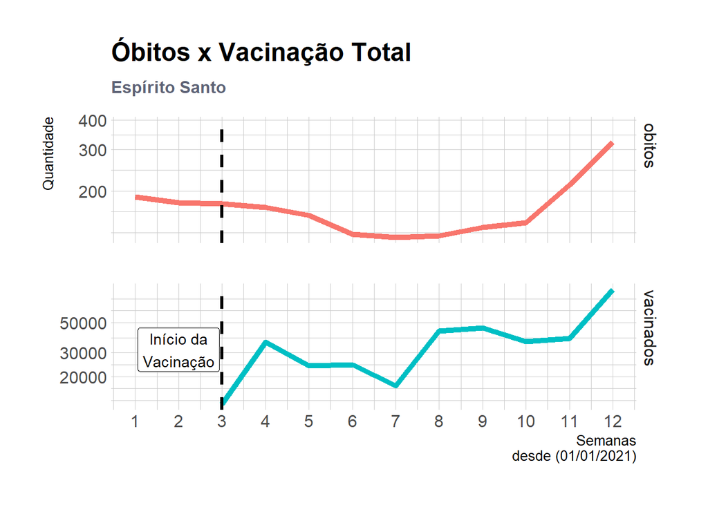

```r
# Vacinação total x Óbito total
covid %>%
  filter(DataObito >= "2021-01-01") %>%
  group_by(week) %>%
  summarise(obitos = n()) %>%
  left_join(y = vacinas %>%
              group_by(week) %>%
              summarise(vacinados = n()),
            by = c("week" = "week")) %>%
  gather("obitos", "vacinados", -week) %>%
  drop_na() %>%
  ggplot() +
  geom_line(aes(x = week, y = vacinados, color = obitos), size = 1.8) +
  facet_grid(obitos ~ ., scales = "free_y") +
  geom_vline(xintercept = 3, size = 1.2, linetype="dashed", color = "black") +
  geom_label(x = 2, y = 4.5, label = "Início da\nVacinação") +
  scale_y_log10() +
  scale_x_continuous(n.breaks = 12, limits = c(1, 12)) +
  scale_color_discrete(guide = FALSE) +
  labs(title = "Óbitos x Vacinação Total", subtitle = "Espírito Santo",
       x = "Semanas\ndesde (01/01/2021)",
       y = "Quantidade",
       colour = NULL) +
  theme_ipsum_pub(base_family = 12, base_size = 12, axis_title_size = 10) +
  theme(legend.text = element_text(NULL),
        plot.subtitle = element_text(vjust = 1, size = 12, colour = "#5E6376", face = "bold"))
```

### **Contato:**

Qualquer dúvida, sugestão ou outros motivos fico a inteira disposição para conversar!

E-mail: victor.passon@yahoo.com.br

Linkedin: https://www.linkedin.com/in/victorpasson/

Github: https://github.com/victorpasson

Site Portfolio: http://victorpasson.github.io/

[Voltar](http://victorpasson.github.io/)